# Exploratory Data Analysis by Skandarajan Rajaratnam

### Plot Two

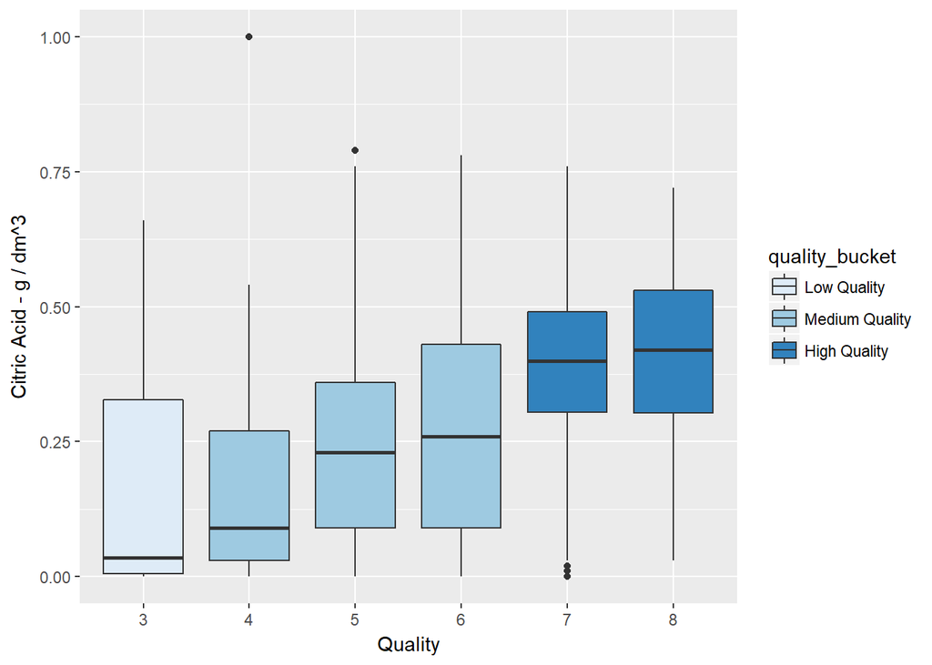

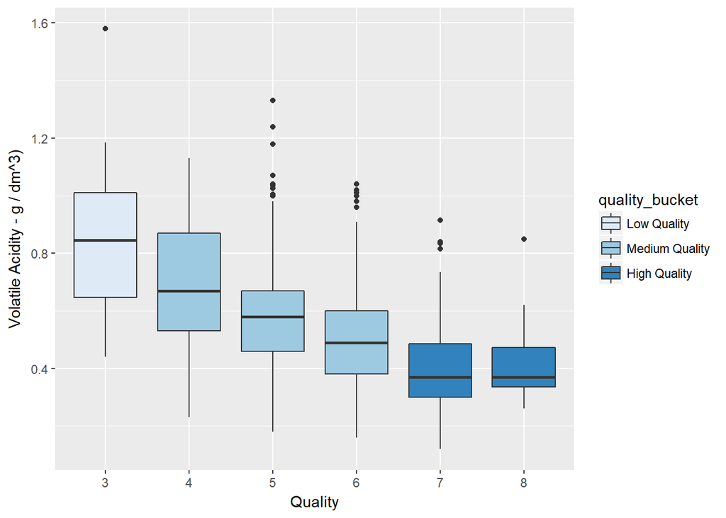

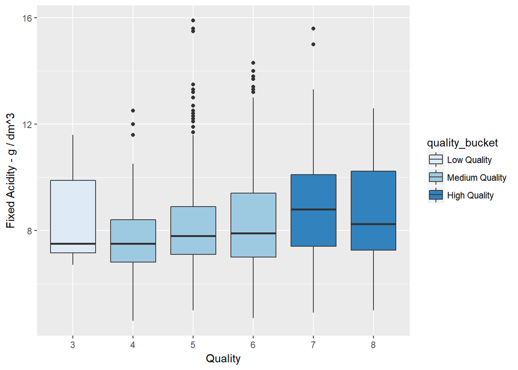

### Plot Three

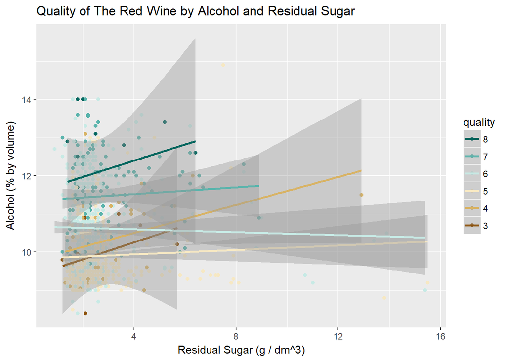

### Description Three

# Reflection

This explores the univariate, bivariate, & multivariate relationships between variables. This data set contains 1,599 red wines with 11 variables on the chemical properties of the wine.

Residual Sugar - This is the amount of sugar left in solution after fermentation has finished. Residual sugar and density have a positive strong correlation. R-squard: Pr values 0.99 and 0.91 accordingly. In wine tasting, the term “acidity” refers to the fresh, tart and sour attributes of the wine which are evaluated in relation to how well the acidity balances out the sweetness and bitter components of the wine. I identified Residual sugar, Alcohol, Acidity and Density are strongly correlated togheter influencing the quality of the wine. Alcohol content appeared to be the number one factor for determining a high quality wine. Citric acid and Sulphates had to be in specific amounts in order for alcohol to influence the taste or quality of the wine.

I observed, Wine with high percent of alcohol content and total acidity tends to be rated as high quality wine. Also wine with low % of alcohol with more total acidity tends to be rated as low quality wine. Based on the result, we can see that the acidity in wine and percent of alcohol content are two important components in the quality and taste of Red wine.

Red wines have deep colors, full bodied, stronger, concentrated flavors and smooth mouthfeel tend to stand out from the assortment more than wines with more subtle characteristics. The process of evaluating wines is very subjective, and experts can be biased by their histories and preferences. It is too complex to make the relation between quality and the other variables using the linear model. Therefore in furture, I think, there are better models or methods (Decision tree learning methods) can be use. We can use machine learning to clasify the quality of wine.

References:

https://classroom.udacity.com/nanodegrees/nd002/parts/0021345407

https://www.statmethods.net/

https://briatte.github.io/ggcorr/#controlling-the-coefficient-labels

https://en.wikipedia.org/wiki/Acids_in_wine